# March Madness 2026

# Introduction

The goal of this model is to maximize your chances of winning your March Madness Bracket.

The purpose of this exercise is not necessarily to build the bracket with the highest expected value but rather to consider both the *true* probability of teams winning and the popularity of other players in your group to pick those teams. The best brackets are not the ones that pick the teams that are most likely to win; it is the brackets that pick winners that are likely to win *and* are not picked in your competitors brackets.

The optimal winners vary based on group size. For a small group, the favorites are good; however, for very large groups (N > 250), more upsets help your chances at winning. **In no way am I guaranteeing a win, simply just increasing the chances of doing so.**

In this years tournament #1 seeds are stronger than ever. Most of them are as likely to make the final four as not. As expected, favorites are popular to pick for the public, but with especially strong one seeds this year, for most group sizes, *chalk* may be the best approach this year.

The optimal team to pick in small-to-medium sizes is **Michigan**. While Duke is the odds-on favorite, it is only slightly. They have an implied 18.5% chance of winning compared to Michigan’s 17.7% chance. At the same time, nearly twice as many people are picking Duke to win it all than Michigan, making Michigan a value pick.

The team to pick in larger group sizes is **Florida**. They also have a edge in expected win percentage compared to popularity, but are less likely to win (and be picked by others). In order to win in large groups, you need variance, so Florida gives you a better chance to stand out in a large group.

The following will walk through the process and results of the model for different group sizes.

# Analysis

The best teams to pick are typically the teams that have a higher expected probability than ‘popular’ probability. Additionally, since the points scale exponentially by round (1 point for first round, 2 for second, 4 for third, etc.) it is more important to pick teams that are undervalued in the later rounds than the early rounds. For example, if a team has a 10% chance to make the final four but only 5% of Yahoo users are picking them to make the final four, that is more valuable than a team that has a 50% chance to make the sweet sixteen but 45% of Yahoo users are picking them to make the sweet sixteen.

The lower-ranked 1 seeds (Michigan and Florida) appear to have relative value in this years bracket. While both teams are overvalued to make the final four (61.2% of brackets picked Michigan to come out of the Midwest region compared to an implied probability of 48%), they are undervalued to make and win the championship, which holds more weight.

This year, double digit seeds are not expected to do well. In fact, the 1st round spreads are some of the largest ever seen. While some have recognized this and adjusted brackets accordingly, many still like to pick upsets regardless of how likely they are to happen. This leads the model to like a relatively chalky bracket even in somewhat larger group sizes.

The other thing to consider is that even if there is an ‘edge’ by picking an underdog to go to the sweet sixteen or further it may not be worth it. The goal is the find the optimal mean-variance tradeoff of your bracket. Picking all the teams that are expected to win will maximize the expected value of you bracket, but it will also minimize the variance. This is good for a small group. This means that even if Michigan State only has a 53% chance of making the sweet sixteen and 77% of Yahoo users picked them to win at least two games, it is not worth picking Louisville or USF because you don’t need the variance. In a larger group you may want the variance and therefore would take the edge over the popular pick.

# Data

There are two main sets of data. The *expected* data and the *popular* data. A few sources were considered for the *expected*, mainly the implied probability from sportsbooks. This can be done by converting the betting odds into a proability and de-vigging (removing the house edge) the odds for each team to make a certain round. The issue with this data is that the amount of vig may not be the same in each line (e.g. a longshot may have more vig as it represents a larger risk to the sportsbook). Additionally, getting this data is manual and tedious. This year, I made some manual adjustments to the odds for very high seeds (>13) to win it all in order for the final implied probabilities to make sense.

In the end, I still believe the implied proability for the top seeds may be muted slightly. For example, Duke is -135 to make the final four which implies a 57.4% chance, but after removing the total vig across all 16 teams that could make it, that implied probabilty drops to 48.5%. This disproportionately affects better seeded teams. Still, the model loves one seeds so this does not concern me too much.

For the popular pick data, until 2023, ESPN would offer *Who Picked Whom* data, but unfortunately Disney had to kill it. CBS also offers it, but in the most immpossibly tedious way - you have to fill out a hypothetical bracket and it will tell you each teams popularity to go to the next round. Luckily Yahoo still offers the public free popularity data.

Of course, the implicit assumption is that the competitors in your group pick like the average user at Yahoo. On the fringes that is unlikely. Especially if they are putting money behind it, I would hope no one is picking 14-seed UPenn to win it all like 0.2% of Yahoo users.

The data is structured as the probability that each team makes it to each round. For example, *Final Four* for Duke means that Duke has a 48.5% chance to *at least* make the final four while 64.2% of Yahoo users are picking them to make it.

The data is admittedly outdated, it was pulled 3/17, so these numbers have changed slighlty for the popular pick. In my opinion, the numbers did not change enough to materially affect results.

Below is the popular data compared to expected data, by round.

## Comparison of Data

### Champion

|  | Seed | Team | Region | Expected | Popular | Value Over Popular |
| --- | --- | --- | --- | --- | --- | --- |
| 1 | 1 | Duke | East | 0.185242196 | 0.292541492 | -0.107299296 |
| 2 | 1 | Michigan | Midwest | 0.177405668 | 0.142971406 | 0.03443426199999999 |
| 3 | 1 | Arizona | West | 0.173654138 | 0.209658068 | -0.03600392999999999 |
| 4 | 1 | Florida | South | 0.098039974 | 0.063587283 | 0.03445269100000001 |
| 5 | 2 | Houston | South | 0.05952427 | 0.055088982 | 0.004435287999999996 |
| 6 | 2 | Iowa State | Midwest | 0.043851213 | 0.019196161 | 0.024655052 |
| 7 | 2 | Connecticut | East | 0.03209642 | 0.035092981 | -0.002996561000000002 |
| 8 | 2 | Purdue | West | 0.03209642 | 0.031493701 | 0.0006027190000000016 |
| 9 | 3 | Illinois* | South | 0.021675505 | 0.0119976 | 0.009677905 |
| 10 | 3 | Michigan State | East | 0.014922751 | 0.013697261 | 0.001225489999999999 |

[output cut: 54 more lines]

### Make Championship

Probability to make the championship - Win or Lose

|  | Seed | Team | Region | Expected | Popular | Value Over Popular |
| --- | --- | --- | --- | --- | --- | --- |
| 1 | 1 | Duke | East | 0.327118679 | 0.486009427 | -0.158890748 |
| 2 | 1 | Michigan | Midwest | 0.312254946 | 0.28157474 | 0.03068020599999999 |
| 3 | 1 | Arizona | West | 0.289484697 | 0.405075939 | -0.115591242 |
| 4 | 1 | Florida | South | 0.174431894 | 0.136495838 | 0.037936056 |
| 5 | 2 | Houston | South | 0.13651533 | 0.135894093 | 0.0006212369999999967 |
| 6 | 2 | Iowa State | Midwest | 0.093628714 | 0.052258193 | 0.041370521 |
| 7 | 2 | Purdue | West | 0.079616253 | 0.074040767 | 0.005575486000000004 |
| 8 | 3 | Illinois* | South | 0.058876652 | 0.033095978 | 0.025780674 |
| 9 | 2 | Connecticut | East | 0.056050573 | 0.071407081 | -0.015356508 |
| 10 | 3 | Michigan State | East | 0.043647225 | 0.038411393 | 0.005235831999999996 |

[output cut: 54 more lines]

### Final Four

|  | Seed | Team | Region | Expected | Popular | Value Over Popular |
| --- | --- | --- | --- | --- | --- | --- |
| 1 | 1 | Duke | East | 0.485835095 | 0.642893069 | -0.157057974 |
| 2 | 1 | Michigan | Midwest | 0.480122324 | 0.612203112 | -0.132080788 |
| 3 | 1 | Arizona | West | 0.471351745 | 0.584363381 | -0.113011636 |
| 4 | 1 | Florida | South | 0.349489029 | 0.419932811 | -0.07044378200000001 |
| 5 | 2 | Houston | South | 0.268334836 | 0.357121042 | -0.08878620599999998 |
| 6 | 2 | Iowa State | Midwest | 0.246262317 | 0.181715807 | 0.06454651 |
| 7 | 2 | Purdue | West | 0.18784944 | 0.158978997 | 0.028870443 |
| 8 | 3 | Gonzaga | West | 0.144040946 | 0.096874686 | 0.04716626 |
| 9 | 3 | Illinois* | South | 0.130748422 | 0.102514507 | 0.028233915 |
| 10 | 2 | Connecticut | East | 0.120845666 | 0.136203601 | -0.015357935 |

[output cut: 54 more lines]

### Elite Eight

|  | Seed | Team | Region | Expected | Popular | Value Over Popular |
| --- | --- | --- | --- | --- | --- | --- |
| 1 | 1 | Michigan | Midwest | 0.695388669 | 0.816939048 | -0.121550379 |
| 2 | 1 | Arizona | West | 0.634726911 | 0.780465307 | -0.145738396 |
| 3 | 1 | Duke | East | 0.62477168 | 0.794171037 | -0.169399357 |
| 4 | 1 | Florida | South | 0.529194256 | 0.775812717 | -0.246618461 |
| 5 | 2 | Iowa State | Midwest | 0.488293737 | 0.534208637 | -0.04591489999999998 |
| 6 | 2 | Houston | South | 0.454086011 | 0.62778853 | -0.173702519 |
| 7 | 2 | Purdue | West | 0.438787443 | 0.506180106 | -0.06739266299999996 |
| 8 | 3 | Illinois* | South | 0.361399828 | 0.217887338 | 0.14351249 |
| 9 | 3 | Gonzaga | West | 0.345956643 | 0.292426918 | 0.05352972500000003 |
| 10 | 2 | Connecticut | East | 0.328689325 | 0.501157757 | -0.172468432 |

[output cut: 54 more lines]

### Sweet Sixteen

|  | Seed | Team | Region | Expected | Popular | Value Over Popular |
| --- | --- | --- | --- | --- | --- | --- |
| 1 | 1 | Michigan | Midwest | 0.847058824 | 0.942422989 | -0.095364165 |
| 2 | 1 | Arizona | West | 0.826883721 | 0.934981968 | -0.108098247 |
| 3 | 1 | Duke | East | 0.823422039 | 0.951103462 | -0.127681423 |
| 4 | 1 | Florida | South | 0.771304676 | 0.91893558 | -0.147630904 |
| 5 | 3 | Illinois* | South | 0.76494382 | 0.670074634 | 0.09486918600000005 |
| 6 | 2 | Iowa State | Midwest | 0.748923423 | 0.760049347 | -0.01112592400000001 |
| 7 | 2 | Purdue | West | 0.718808543 | 0.819569672 | -0.100761129 |
| 8 | 3 | Gonzaga | West | 0.708235294 | 0.605331458 | 0.102903836 |
| 9 | 2 | Houston | South | 0.691701089 | 0.86347391 | -0.1717728209999999 |
| 10 | 2 | Connecticut | East | 0.620186047 | 0.803670465 | -0.1834844179999999 |

[output cut: 54 more lines]

# Process

Given the unimaginable amount of bracket combinations, a simulation, rather than discrete, approach is used.

First a set of 10,000 outcomes is simulated using the expected probabilities of each team to make it to each round. Next, a group of size N, is simulated for each of those 10,000 simualtions. The distribution of the group brackets is based on the popular pick data. The brackets in those groups are graded and the necessary amount of points to win is determined.

Next, 1,000 brackets are created sampling from the expected probabilities. They are graded based on each of the 10,000 outcomes/groups and we see how many groups each bracket wins.

The top 25% of brackets are determined. The sampling for the next 1,000 testing brackets will be sampled from a weighted distribution of the initial expected probabilities and the distribution of the best brackets from the prior iteration. This a process known as **Genetic Sampling**. I used up to 10 interations, but cut it off if a bracket won 3 times in a row.

The top 5% of brackets are rolled over to the next round of simulation to test against a new set of outcomes.

The next round of simulation begins by creating 10,000 new outcomes.

# Results (Group Size = 5)

For a very small group of 5 the optimal bracket is basically all chalk up until the final four. As mentioned in the Intro, Michigan is the best pick in this group size. They are expected to win 17.7% of the time but only 14.3% of Yahoo users are picking them to win, making them a value pick. In a small group you do not need a lot of variance.

The expected value of a random bracket in a 5 person pool is 20%. Using this bracket the expected win percentage is ~35.6%. That means for a $20 buy your expected winnings increases from $0 to $15.6!

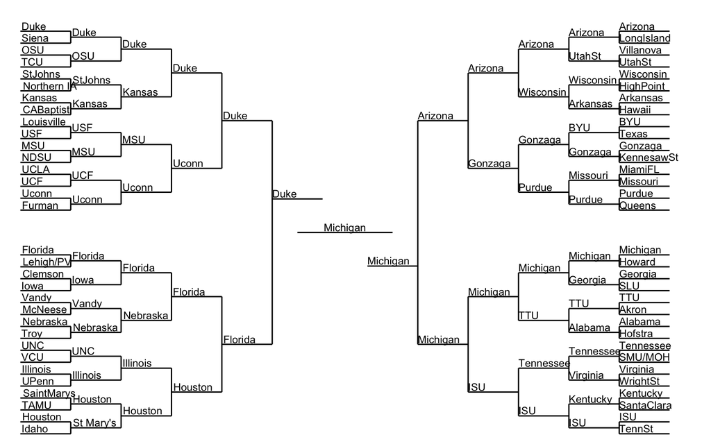

# Results (Group Size = 20)

For a slightly larger group the results would still be considered chalky. The bracket is pretty similar to the 5 person bracket.Though now at least one 3 seed makes the elite eight.

The expected value of a random bracket is 5%. Using this bracket it is ~12%. For a $20 buy in the expected value goes from $0 to $28.

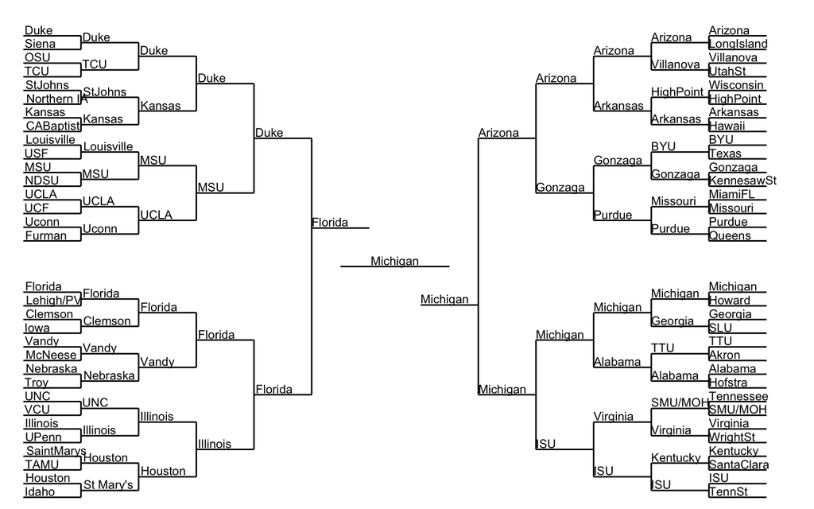

# Results (Group Size = 50)

For a now larger group size, Florida becomes the optimal winner to pick. Just like Michigan, Florida is undervalued compared to the other top teams. In this larger group, though, you need more variance to be the #1 bracket, therefore the less-likely-to-win team, Florida, is better than Michigan. Notice there are still not a ton of upsets. The upsets in this optimal bracket are where they matter - the semifinals and finals.

The expected value of a random bracket is 2%. Using this bracket it is ~5.9%. For a $20 buy in the expected value goes from $0 to $39.

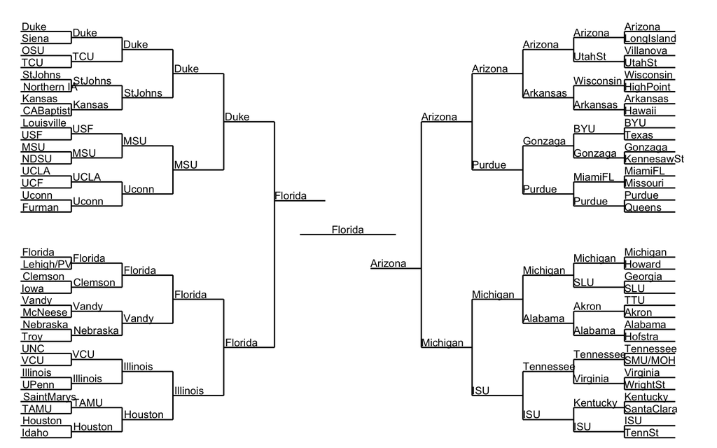

# Results (Group Size = 75)

I had the chance to submit four brackets in a 75 person pool. Using the optimal 75 person bracket as a seed competitor, I optomized for the next best bracket to win in cases that the original does not. I did this iteratively with 1, 2, and 3 seed brackets to create the 4 that have the combined best chance to win.

These four brackets combine an for an expected win percentage of 13.2% in a 79 person pool. That is roughly 8.1% above expected value.

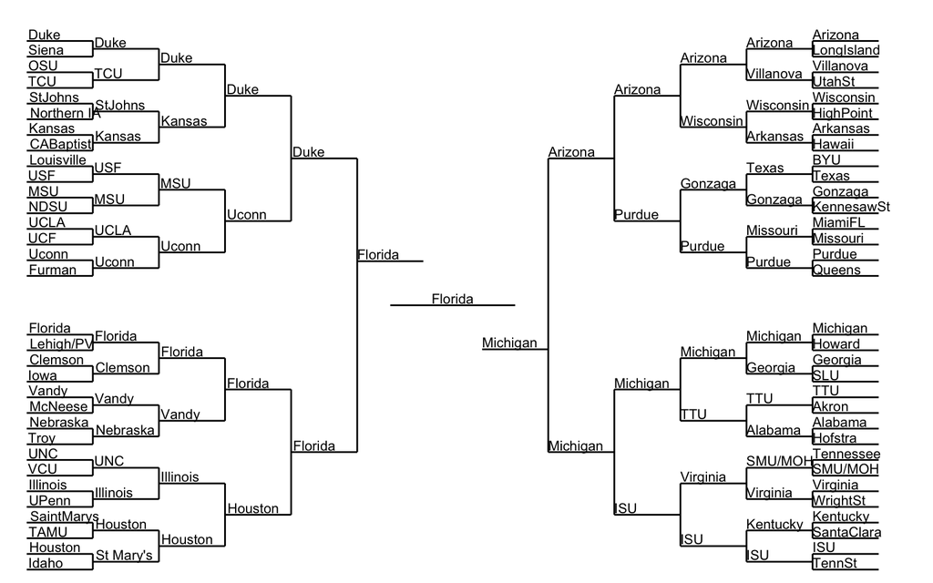

# Results (Group Size = 75; 2nd Bracket)

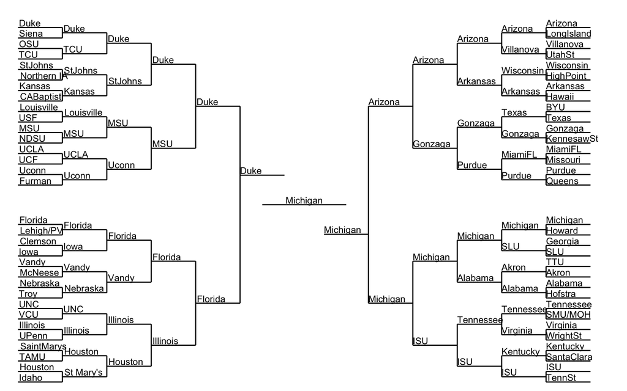

# Results (Group Size = 75; 3rd Bracket)

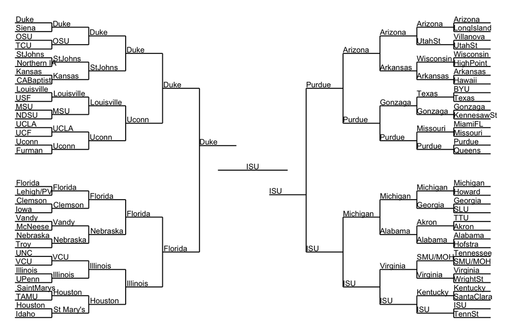

# Results (Group Size = 75; 4th Bracket)

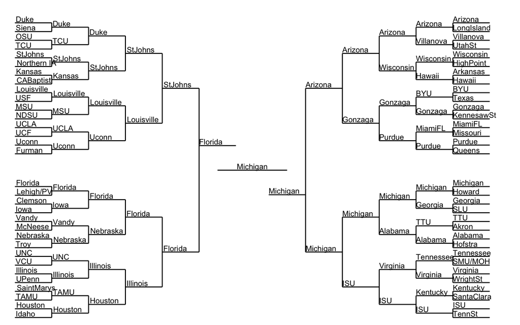